# Teach the room you have

Week 12 · Chapters 11 and 12 · Applied motivation and the context of learning

Study · Week 12

Read Chapters 11 and 12 of the textbook (Eggen & Kauchak, 2025) before you read this brief. Two weeks of theory now become decisions about how you design a task, what you praise, and how you manage a classroom. You will also consider one more motivation, your own.

About 40 minutes plus Dr. Cho’s video: reading, two places you stop and write, and fourteen quick checks.

Then watch **Dr. Hyeree Cho’s short video** on teacher motivation in Canvas.

## Start with your own two profiles

You have measured yourself twice. In Week 10, *What works on you?* showed how strongly reward and punishment affect you. In Week 11, *What moves you?* showed why you work in a course, and whether you think you can do it.

Open both results. Then look at the behavior plan you wrote in Week 10 and the motivation rule you wrote in Week 11.

When we did this in Week 10, most of you found the same thing: **the plan you wrote uses what works on you.** A student who loves public praise planned public praise, and a student who hates being called out planned no call-outs. Keep both profiles open this week, because you will need them Tuesday and Thursday.

## A belief novice teachers may have

**If it worked for me, it will work for them.** The belief feels like experience, but it rests on one data point, which is you.

People overestimate how many others share their own preferences and reactions. Psychologists call this the **false consensus effect** (Ross et al., 1977), and teachers show it too. You chose to become a teacher, and you liked school enough to come back to it, which already makes you unusual among the people you will teach.

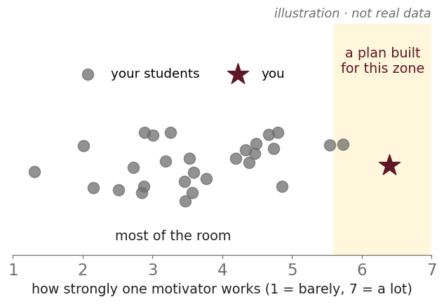

Your profile and the room. A plan built for what works on you fits the few students who are like you.

**The most dangerous recipe in teaching is to assume your students learn the way you do.** The solution is simple: ask them, and watch them.

True or false?

A teacher who was highly motivated by grades as a student can safely assume most of their students will be too.

Not quite That is the false consensus effect. People who chose teaching are unusual among the students they teach, so your own profile is one point in the room.

Right One person’s profile is one point. People overestimate how many others share it, and teachers do too.

## Teacher qualities that motivate students

Chapter 11 puts the teacher at the center of a model for motivating students. Part of what motivates a class is *who the teacher is*, before any lesson plan.

Caring Students who believe the teacher cares about them as people work harder for that teacher. Teachers show care when they learn students’ names, ask about their lives, and hold them to a standard.

Modeling and enthusiasm Students watch what you value. *“I’m not crazy about this unit either, but it’s on the test”* models that the content isn’t worth caring about. Real interest in your subject is contagious, and so is boredom.

Positive expectations Teachers show their expectations in small acts, such as whom they call on, how long they wait for an answer, and how much they help. A teacher who never calls on a struggling student “to spare them” tells that student what she expects of them.

Teaching efficacy A teacher’s belief that they can reach students, including those who are hardest to reach (Tschannen-Moran & Woolfolk Hoy, 2001). It is Bandura’s self-efficacy applied to teaching. Teachers high in it keep trying with the student who isn’t getting it.

Autonomy support This quality puts Week 11’s C.A.R.E. into practice with real choices, reasons for the task, and room for students’ views.

Check yourself

Mr. Hale tells a colleague, *“I don’t call on Jaylen or Brianna. They struggle, and I don’t want to embarrass them.”* Which teacher quality is he showing, and how will it likely land on the two students?

The intention is kind The message is different, because students notice who never gets asked. Being skipped tells them what the teacher expects of them.

Nobody chose He decided for them. Autonomy support would mean giving them a real choice, like a heads-up before he calls on them.

Yes The intention is kind and the expectation is low. Fewer chances to answer means fewer chances to succeed, and the students understand the message. A heads-up (“I’ll come to you for number 3”) protects them and still expects something.

The opposite A teacher high in efficacy believes he can reach these two. Skipping them suggests he doesn’t.

## Teachers’ own motivation

Teachers need motivation too, and many lose it. In a 2022 poll of its members, the National Education Association found that 55 percent of educators planned to leave the profession sooner than they had expected (National Education Association, 2022). The poll reports a stated plan, from union members during the pandemic, and it is still a warning.

Dr. Hyeree Cho studies how **pre-service teachers**, students like you in someone else’s classroom, keep themselves motivated in their field placements (Cho, 2025). Her video is your other assignment this week. Two ideas come from her work:

Motivation regulation A person’s deliberate effort to monitor and control their own motivation (Wolters, 2003). It is self-regulation applied to motivation, so when your motivation drops, you do something about it on purpose.

The strategies People raise their own motivation in a few ways. They remind themselves of a **value**: this matters to who I am (attainment), this will be useful (utility), or I can find the interesting part (interest). They use **self-talk**: keep going to learn as much as you can (mastery), to get a good grade (performance-approach), or so you don’t look foolish (performance-avoidance). They also **self-consequate**, which means they promise themselves a reward when the work is done.

You already know the theory behind every one of those strategies. Self-consequating is Week 10’s reinforcement, delivered to yourself. Value regulation is Week 11’s expectancy-value theory, and self-talk is goal orientation.

Check yourself

Ten minutes before your lesson, your host teacher changes half of it. You tell yourself, *“However this goes, I’ll learn something about teaching from it.”* Which motivation regulation strategy is that?

Close Utility would be “this will be useful for my job later.” Yours is about learning as much as you can, right now.

Yes You keep going to learn as much as you can, so you are giving yourself a mastery goal.

No fear here Performance-avoidance would be “don’t look foolish in front of your host teacher.”

No reward promised Self-consequating promises yourself something when the work is done.

These strategies connect with this week’s warning. **The strategies you use on yourself are the ones you will reach for with students.** A teacher who keeps going by promising herself a reward will promise rewards. A teacher who keeps going so she won’t look foolish may manage students through that fear.

True or false?

Promising yourself a coffee after you finish grading is a behaviorist strategy, applied to your own motivation.

Right That is **self-consequating**, a reinforcer you deliver to yourself, contingent on the behavior. It applies Week 10 to your own motivation.

Look again A reward that follows a behavior and makes it more likely is reinforcement. Delivering it to yourself makes it **self-consequating**, one of the motivation regulation strategies.

## Design for motivation: TARGET

Week 11’s theories explain why a student works, and Chapter 11 asks what a teacher can *change*. One useful checklist is **TARGET**, six features of a classroom that push students toward mastery goals or performance goals (Ames, 1992; Epstein, 1989).

|  | **Leans toward mastery** | **Leans toward performance** |
| --- | --- | --- |
| **Task** | Varied, a little hard, with a clear purpose | The same worksheet, every day |
| **Authority** | Students make real choices | The teacher decides everything |
| **Recognition** | For progress and effort, given privately | For being the best, in public |
| **Grouping** | Mixed, changing groups | Fixed “high” and “low” groups |
| **Evaluation** | Against criteria, with chances to revise | Against each other, once |
| **Time** | Flexible, so students can finish well | Speed is rewarded |

True or false?

Posting the top five test scores on the wall supports mastery goals, because students can see what success looks like.

Not quite Public recognition for being the best is the performance column of TARGET. It tells everyone below the top five how they compare, and that is the message most of them take.

Right Public recognition for being the best pushes toward performance goals. Showing a strong example of the work, with criteria, does the job without ranking anyone.

Commit first

Mr. Davila is a third-year high school teacher who dreads coming to work. He posts a **Wall of Fame** with the top five scorers each unit, and he gives **bonus points for speedy correct answers**. His students only ask, *“Is this on the test?”* He compares his scores to other teachers’ all the time. He has started using sarcasm when students give wrong answers: *“it gets a laugh, so at least someone is paying attention.”* He once bribed the class with a pizza party, and they just got louder.

**Use two letters of TARGET to explain why his students only ask “Is this on the test?” Then name one thing about Mr. Davila’s own motivation.** Two or three sentences.

**At least Recognition and Time explain the question.** The Wall of Fame rewards being the best, in public, and the bonus for speed rewards fast answers over careful ones. Evaluation fits too, because everything is a contest. A classroom organized this way teaches one question, *what counts?*, and his students ask it.

**His own motivation depends on comparison.** He measures himself against other teachers, which is a performance goal for his own career, and his teaching efficacy is sinking. The sarcasm is a sign, because he gets a laugh where he can’t get learning. He organized his classroom around the same motivation he uses on himself.

## Praise and feedback

Week 10 showed that praise teaches only when it depends on what the student did. Chapter 11 adds two rules:

- **Praise the process.** Name effort, strategy and improvement specifically. Children praised for being smart chose easier tasks afterward and did worse after a failure, whereas children praised for effort chose harder tasks and kept going (Mueller & Dweck, 1998).
- **Give information.** “Your second paragraph finally answers the question, because you used the source” tells a student what to do again. “Great job!” tells them only that you’re pleased.

Your Friction Move this week starts with a decision: should a teacher hand this feedback to AI at all? Before any AI, you write your own encouragement for a student who studied hard and got a C−. Then you compare it with the response of an AI given these two rules. Notice where your intuition and the theory disagree.

Check yourself

A student fixes a lab report after feedback, and the conclusion now matches the data. Which comment fits Chapter 11 best?

Praise for the person “Natural” makes success about ability. Students praised this way tend to avoid the next hard task.

Yes The comment is specific, it is about the strategy, and it tells the student exactly what to do again.

Warm and empty It carries no information about what worked.

Comparison Ranking against classmates is the performance column of TARGET.

### Grades, ranks, and charts

Grades motivate, and they also teach students to ask what counts. In Week 10’s case, the points chart taught Mila to ask which option was worth more. In this week’s case, Mila asks which part of the group task is graded, then which part is worth the most. Public tracking adds comparison, because every score becomes a statement about who is ahead. Chapter 11 gives clear advice: grade against criteria, let students revise, and keep individual grades private.

## Goals and self-regulation

Week 10 left one question open. When you counted your phone checks, counting changed the count. That is **self-monitoring**, and it belongs to a larger skill, **self-regulated learning**. A self-regulated learner plans, watches, and adjusts their own learning toward a goal. The lecture’s fourth question, *how do I do this?*, referred to this skill.

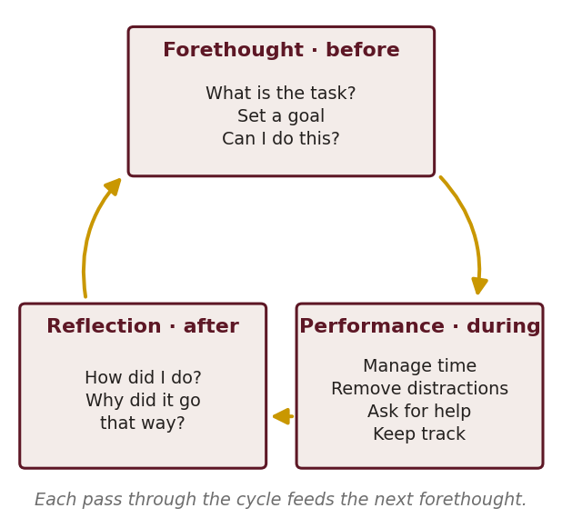

The self-regulation cycle. Forethought comes before the task, performance during it, and reflection after it, and then the cycle begins again.

The cycle has three phases (Zimmerman, 2002). In **forethought**, the learner analyzes the task, sets a goal, and judges whether they can do it. In **performance**, they manage time, remove distractions, ask for help, and keep track. In **reflection**, they judge how they did and explain why. That explanation is an attribution, which you studied in Week 11, and it influences the next cycle.

**Good goals are close and specific.** Children working through a math program with a goal for each session learned more, and believed more in their own ability, than children given one distant goal for the whole program (Bandura & Schunk, 1981). The lecture’s version is the SMART goal: specific, measurable, achievable, relevant, time-bound.

True or false?

“Finish problems 1 to 10 tonight and check them against the key” is a better goal for a struggling student than “do well in math this semester.”

Right The goal is close and specific. The student can meet it tonight and see that they met it, and that success is a mastery experience.

Look again Distant, vague goals give no feedback until it’s too late. Close, specific goals let a student see progress, which builds self-efficacy.

Check yourself

After a quiz, a student writes, *“I got 6 of 10. I missed every question on the second reading, so next time I’ll reread before the quiz instead of skimming.”* Which phase of the cycle is this?

Yes She judges the result and explains it. Her explanation is a strategy, which she controls, and that reflection feeds her next forethought.

Close Her plan for next time will be forethought. Right now she is looking back at what happened.

The quiz is over Performance happens during the task.

Both It is an attribution, and attributions are how the reflection phase works. The theories connect.

## Belonging

Students work harder where they believe they belong, and belonging is fragile for students who worry that people like them don’t succeed here.

Stereotype threat The worry of confirming a negative stereotype about your group, which can lower performance on the very task the stereotype is about (Steele & Aronson, 1995). The worry takes up working memory.

True or false?

Stereotype threat can lower a capable student’s score, because worry about confirming the stereotype takes up working memory.

Right The student knows the material. The worry crowds the space they need to use it.

Not quite Look again. The worry uses working memory, the same limited space the test needs, so a capable student can score lower.

Belonging interventions Short activities that tell students that worry about belonging is common and fades with time. In one study, a single session of this kind in the first year of college improved Black students’ grades over the next three years (Walton & Cohen, 2011).

**The size of the effect matters.** These interventions have real effects, but they are not magic (Yeager & Walton, 2011). They work in some schools and not in others, and they work best where the classroom already supports the message. A one-time activity in a class where a student is mocked and nobody reacts will do nothing.

True or false?

A belonging activity on the first day of class will protect students from stereotype threat for the rest of the year, whatever happens in the room afterward.

Not quite The effects depend on the context. They last where the room keeps backing up the message.

Right The activity is not magic. The message has to be true in the room, every day after.

## Classroom management

Chapter 12 defines classroom management as creating an environment where learning can happen, and most of it is **prevention**.

Rules and procedures Rules say how to behave. Procedures say how things get done, such as entering, getting materials, turning in work, sharpening a pencil or going to the bathroom. A class without procedures spends its time on these tasks, and Mr. Davila has none.

True or false?

“Turn in your homework in the blue tray as you come in” is a classroom rule.

Not quite It says how something gets done, so it is a **procedure**. Rules say how to behave, like “respect each other’s work.”

Right It is a **procedure**, because it says how a routine task gets done. Rules are about behavior.

Withitness Knowing what is going on everywhere in the room, and showing students that you know (Kounin, 1970). A teacher with withitness catches the small problem early, and catches the right student.

Overlapping, momentum, smoothness Overlapping is handling two things at once, such as helping one group while glancing at another. Momentum is keeping the lesson moving without dead time, where most misbehavior starts. Smoothness is moving between activities without stopping the whole class.

Responding Start with the least intrusive move, such as a look, moving closer, or a quiet word, and escalate only if needed. Sarcasm and yelling escalate the situation for you. **Restorative** responses ask what harm was done and how to repair it, which keeps the student in the community.

Relationships Every one of these strategies works better with a student who trusts you. Across many studies, warm, encouraging teacher-student relationships go with more engagement and better learning (Cornelius-White, 2007).

Culturally responsive and sustaining teaching Teaching that holds high expectations, draws on students’ cultures as strengths, and helps students question what they’re given (Ladson-Billings, 1995). *Sustaining* adds that students’ languages and cultures are worth keeping, beyond being a bridge to the curriculum (Paris, 2012).

Families are part of the environment too. A student’s motivation develops at home as well as in your classroom, and a phone call that starts with something good makes the next conversation easier.

Check yourself

While helping a small group at the back table, Ms. Ortiz notices two students across the room passing a phone. Without leaving the group, she says, *“Marcus, Dee, phones in the bin, thanks,”* and keeps helping. Kounin would call this:

Part of it Her lesson keeps moving, yes. The bigger skill is seeing across the room and handling it while still helping the group.

Nothing to repair yet Restorative responses address harm done. This is a quick redirect.

The opposite A short, calm cue is the least intrusive move she has.

Yes She knew what was happening across the room (withitness) and dealt with it while helping a group (overlapping), and she named the right students.

Commit first

In this week’s case, the room is loud. The teacher raises her voice for the first time, and the room becomes quieter for about ninety seconds.

**Name what happened, in Week 10’s terms, for the students and for the teacher. Why are the ninety seconds the important part?** Two or three sentences.

**For the students, the raised voice is presentation punishment, and it suppressed the noise for a while.** Punishment tends to stop a behavior in the moment without teaching a replacement, so the noise came back.

**For the teacher, it was negative reinforcement.** The noise stopped right after she yelled, which makes yelling more likely next time, and it will need to get louder to work. The ninety seconds show that the problem was never solved, because nothing changed about the task, the groups, or the time of day.

## AI planning tools and their limits

In the case, the teacher asks an AI planning tool how to improve the lesson. It suggests a timer for each phase, assigned roles, a visible checklist, and an exit ticket. All four suggestions are reasonable, and all four are about the task, because the tool only knew the task.

A planning tool will tend to give you a teacher’s average answer, because it cannot see your classroom. It does not know that the lesson was last period on a Friday, which groups were working, or what happened to one student halfway through. It is also built on what works for most people, which is the false consensus problem at a larger scale.

Your Milestone 3 tool has the same limit. You wrote your feedback rule (Week 10) and motivation rule (Week 11) for a learner you imagined, and on Thursday you check them against learners who are different from you.

## Check yourself

Check yourself

A new teacher loved timed math competitions as a kid, so she runs one every Friday. A third of the class starts dreading Fridays. Which idea from this week best explains her choice?

Withitness is noticing the room Her problem started before class: she designed for herself.

Not this time Some students may feel it, but the case is about why she chose the competition.

Yes She assumed that what motivated her would motivate them. Timed competition is also the performance column of TARGET, because it rewards speed, in public, against others.

That’s a strategy for yourself Self-consequating is rewarding your own work. She is choosing a motivator for others.

Check yourself

A teacher wants to change Evaluation in TARGET to support mastery goals. Which change does that?

Still comparison A class average invites everyone to place themselves against it.

Yes Criteria replace ranking, and students get a second chance. Both say that the goal is getting it right.

That’s Time Rewarding speed pushes toward performance, and it is the Time letter.

Good, and a different letter A real choice is Authority. The question asked about Evaluation.

By now you should **Have an answer to case question 1**, which asks which of the six things that went wrong are about how the lesson was set up, and which are about the students.

**Your two profiles, open, and your Week 10 plan and Week 11 rule beside them.** Where does your plan use what works on you? *In person:* bring all four Tuesday. *Online:* have them ready for this week’s discussion.

**On Tuesday we read something together, in class.** Don’t look for it in advance. *Online:* the reading is in this week’s discussion board.

*This week feeds Milestone 3: your tool’s rules, checked against learners who are different from you.*

## Sources

Ames, C. (1992). Classrooms: Goals, structures, and student motivation. *Journal of Educational Psychology, 84*(3), 261–271.

Bandura, A., & Schunk, D. H. (1981). Cultivating competence, self-efficacy, and intrinsic interest through proximal self-motivation. *Journal of Personality and Social Psychology, 41*(3), 586–598.

Cho, H. (2025). *Preservice teachers’ motivation regulation in field experiences* [Doctoral dissertation, Purdue University].

Cornelius-White, J. (2007). Learner-centered teacher-student relationships are effective: A meta-analysis. *Review of Educational Research, 77*(1), 113–143.

Eggen, P. D., & Kauchak, D. P. (2025). *Using educational psychology in teaching* (12th ed.). Pearson. **This week: Chapters 11 and 12.**

Epstein, J. L. (1989). Family structures and student motivation: A developmental perspective. In C. Ames & R. Ames (Eds.), *Research on motivation in education* (Vol. 3, pp. 259–295). Academic Press.

Kounin, J. S. (1970). *Discipline and group management in classrooms.* Holt, Rinehart & Winston.

Ladson-Billings, G. (1995). Toward a theory of culturally relevant pedagogy. *American Educational Research Journal, 32*(3), 465–491.

Mueller, C. M., & Dweck, C. S. (1998). Praise for intelligence can undermine children’s motivation and performance. *Journal of Personality and Social Psychology, 75*(1), 33–52.

National Education Association. (2022, February 1). *NEA survey: Massive staff shortages in schools leading to educator burnout; alarming number of educators indicating they plan to leave profession* [Press release].

Paris, D. (2012). Culturally sustaining pedagogy: A needed change in stance, terminology, and practice. *Educational Researcher, 41*(3), 93–97.

Ross, L., Greene, D., & House, P. (1977). The “false consensus effect”: An egocentric bias in social perception and attribution processes. *Journal of Experimental Social Psychology, 13*(3), 279–301.

Steele, C. M., & Aronson, J. (1995). Stereotype threat and the intellectual test performance of African Americans. *Journal of Personality and Social Psychology, 69*(5), 797–811.

Tschannen-Moran, M., & Woolfolk Hoy, A. (2001). Teacher efficacy: Capturing an elusive construct. *Teaching and Teacher Education, 17*(7), 783–805.

Walton, G. M., & Cohen, G. L. (2011). A brief social-belonging intervention improves academic and health outcomes of minority students. *Science, 331*(6023), 1447–1451.

Wolters, C. A. (2003). Regulating motivation: Deepening the understanding of self-regulated learning. *Educational Psychologist, 38*(4), 189–205.

Yeager, D. S., & Walton, G. M. (2011). Social-psychological interventions in education: They’re not magic. *Review of Educational Research, 81*(2), 267–301.

Zimmerman, B. J. (2002). Becoming a self-regulated learner: An overview. *Theory Into Practice, 41*(2), 64–70.